# LSCA Individual Assignment

Nonthapat Arparpardh

2025-03-13

#### Report Structure:

## Store 46673 (California, Ninth Street)

- Initial Observations, Time-series decomposition, Train-Test split
- Training data Plot and Time Series Decomposition
- **Q1.** Holt-Winters model
- **Q2.** ARIMA model
- **Q3.** Performance comparison

## Store 4904 (California, Shattuck Sq)

- Initial Observations, Time-series decomposition, Train-Test split
- Training data Plot and Time Series Decomposition
- **Q1.** Holt-Winters model
- **Q2.** ARIMA model
- **Q3.** Performance comparison

## Store 12631 (New York, Myrtle Avenue)

- Initial Observations, Time-series decomposition, Train-Test split
- Training data Plot and Time Series Decomposition
- **Q1.** Holt-Winters model
- **Q2.** ARIMA model
- **Q3.** Performance comparison

## Store 20974 (New York, Whitney Avenue)

- Initial Observations, Time-series decomposition, Train-Test split
- Training data Plot and Time Series Decomposition
- **Q1.** Holt-Winters model
- **Q2.** ARIMA model
- **Q3.** Performance comparison

## Q4. Final Forecast (using the optimal model amongst all the models)

### Store 46673 (California, Ninth Street)

#### Initial Observations

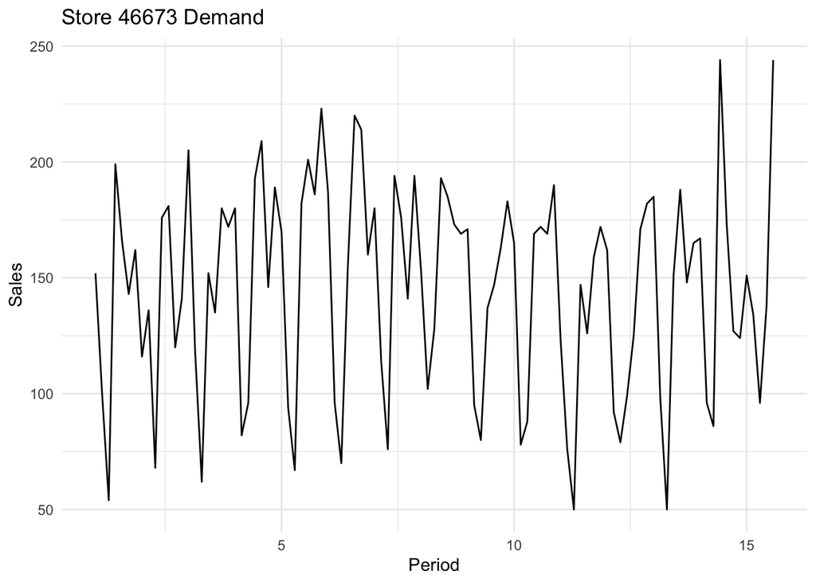

#### Time-series decomposition

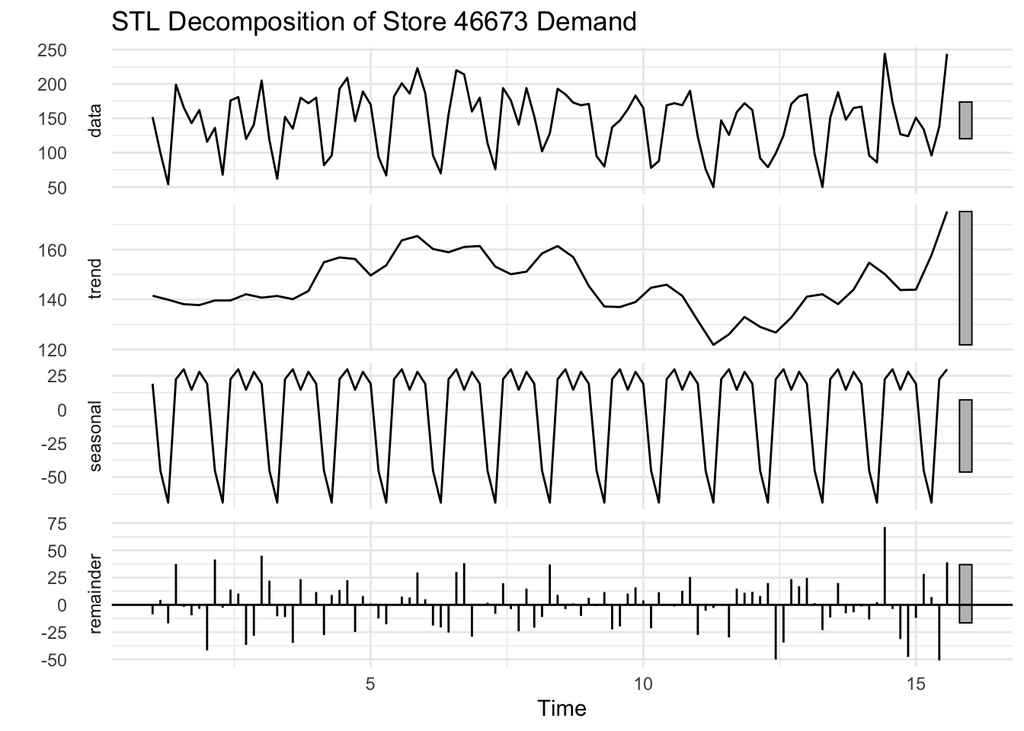

#### Train-Test split

```
## Time Series:
## Start = c(1, 1)
## End = c(13, 5)
## Frequency = 7
##  [1] 152 100  54 199 166 143 162 116 136  68 176 181 120 141 205 118  62 152 135
## [20] 180 172 180  82  96 193 209 146 189 170  94  67 182 201 186 223 187  96  70
## [39] 156 220 214 160 180 114  76 194 176 141 194 153 102 128 193 185 173 169 171
## [58]  95  80 137 147 163 183 165  78  88 169 172 169 190 123  76  50 147 126 159
## [77] 172 162  92  79  99 125 171 182 185  98  50 151 188
```

```
## Time Series:
## Start = c(13, 6)
## End = c(15, 5)
## Frequency = 7
##  [1] 148 165 167  96  86 244 173 127 124 151 134  96 138 244
```

#### Training data Plot and Time Series Decomposition

By observing the plotted time series of the training data, there aren’t any clear indication of the time series being non-stationary, however, observing just the plot is insufficient. Therefore, through observing the time series decomposition of the training data, it can be seen that there is no trend as the grey-bar is relatively large. However, there is a significant seasonal factor as depicted by the small grey-bar in the seasonal plot.

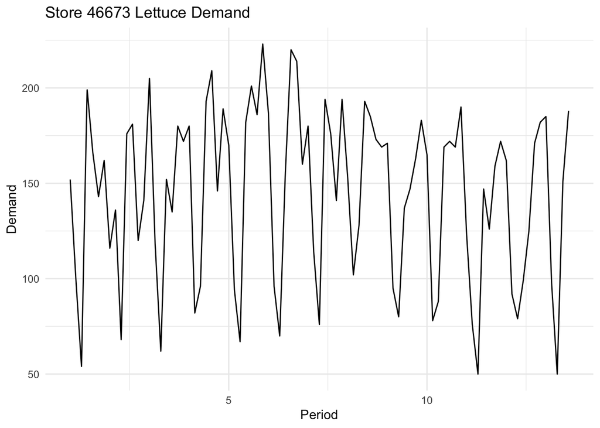

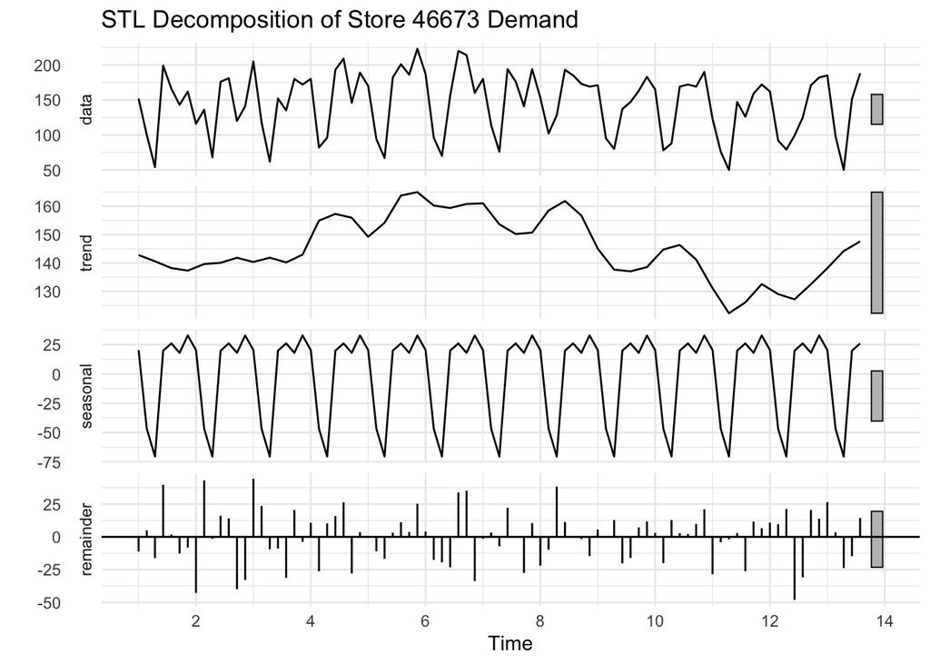

#### Q1. Holt-Winters model

For the Holt-Winters model, the modelling will use the ets() function as the HoltWinters() function requires information to construct the initialisation which is hard to obtain.

To determine the parameters of the ets() function, the automatic model selection function of the ets() function will be used. Additionally, the analysis of the time series decomposition will be used to verify the parameters.

```
## ETS(A,N,A)
##
## Call:
## ets(y = store_46673_train, model = "ZZZ")
##
##   Smoothing parameters:
##     alpha = 0.0946
##     gamma = 1e-04
##
##   Initial states:
##     l = 146.0165
##     s = 32.6444 19.1329 25.5759 20.8428 -70.5411 -47.1212
##            19.4663
##
##   sigma:  24.3637
##
##       AIC      AICc       BIC
##  978.3710  981.1915 1003.2574
```

This is reflected by the decomposition where there is no particular trend as depicted by the large grey bar. Seasonal fluctuations remain approximately constant over time, regardless of the time, therefore is additive.

Thus it is concluded that the optimal Holt-Winters model is ETA(A,N,A)

#### Q2. ARIMA model

For the ARIMA model, the Box-Jenkins procedure will be performed to select and evaluate the best model.

To formally test for the data’s stationarity, the ADF, PP and KPSS tests will be performed. The stationarity tests indicate that the data is stationary.

```
##
##  Augmented Dickey-Fuller Test
##
## data:  store_46673_train
## Dickey-Fuller = -7.7984, Lag order = 4, p-value = 0.01
## alternative hypothesis: stationary
```

```
##
##  Phillips-Perron Unit Root Test
##
## data:  store_46673_train
## Dickey-Fuller Z(alpha) = -52.779, Truncation lag parameter = 3, p-value
## = 0.01
## alternative hypothesis: stationary
```

```
##
##  KPSS Test for Level Stationarity
##
## data:  store_46673_train
## KPSS Level = 0.15893, Truncation lag parameter = 3, p-value = 0.1
```

However, as the observed time series decomposition suggests, there is a clear seasonal factor in the data set although the ADF, PP and KPSS only captures the existence of trend and not seasonlity. Therefore the differencing orders for both non-seasonal and seasonal component must be determined. And results show that although there is no differencing required for non-seasonal, first-order seasonal differencing is required for the data due to its seasonality.

```
## [1] 0
```

```
## [1] 1
```

An initial observation can be made through the ACF and PACF of the training data to get an overview of the ARIMA model. It can be seen in the ACF plot that there are significant spikes on the 7th, 14th and 21st day. This suggests that there is a strong presence of seasonal pattern with a period of 7, in other words there is a weekly seasonality where each same day of the week is highly correlated. For the Seasonal ARIMA model, these recurring spikes in the ACF may indicate the existence of a seasonal MA component as seen from the spikes of lags 7, 14 and 21. Whereas the PACF plot shows a spike in lag 2 which then exponentially decays, along with the previously observed spike (in the ACF) in lag 7. This suggests a potential non-seasonal AR component, where there is an observed direct correlation between the current period and observation in period + 2, thus the spike at lag 7 supports the observed seasonality in the ACF and through the output of the nsdiffs() function of 1. This suggests a seasonal differencing is required.

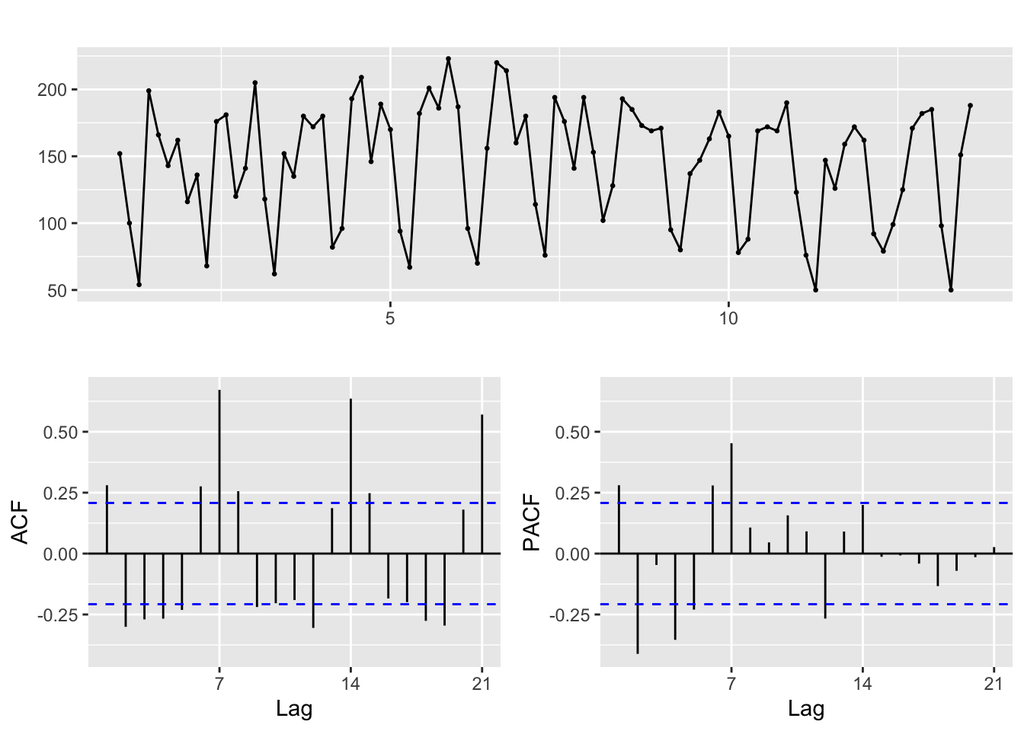

After applying the first-order seasonal differencing of lag 7, both the ndiffs() and nsdiffs() functions now has an output of 0. This indicates that the data does not require any differencing and is stationary.

```
## [1] 0
```

```
## [1] 0
```

To further verify, the stationarity tests are also performed, thus results confirms that the data is stationary.

```
##
##  Augmented Dickey-Fuller Test
##
## data:  store_46673_train_diff1
## Dickey-Fuller = -3.613, Lag order = 4, p-value = 0.03748
## alternative hypothesis: stationary
```

```
##
##  Phillips-Perron Unit Root Test
##
## data:  store_46673_train_diff1
## Dickey-Fuller Z(alpha) = -74.087, Truncation lag parameter = 3, p-value
## = 0.01
## alternative hypothesis: stationary
```

```
##
##  KPSS Test for Level Stationarity
##
## data:  store_46673_train_diff1
## KPSS Level = 0.097681, Truncation lag parameter = 3, p-value = 0.1
```

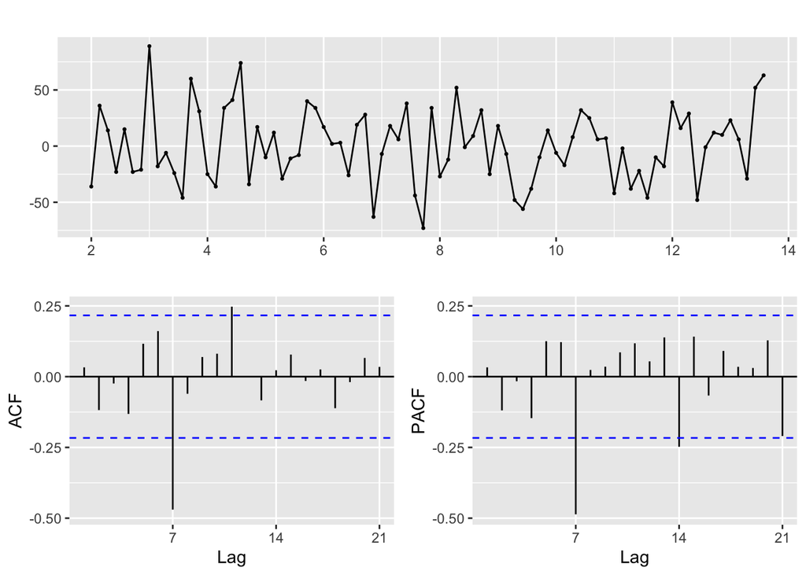

After using the various statistical testing to rationalize the differencing and characteristics of the data, the auto.arima() function is used to suggest the optimal model.

```
##
##  ARIMA(2,1,2)(1,1,1)[7]                    : Inf
##  ARIMA(0,1,0)(0,1,0)[7]                    : 847.6902
##  ARIMA(1,1,0)(1,1,0)[7]                    : 808.2918
##  ARIMA(0,1,1)(0,1,1)[7]                    : 771.4907
##  ARIMA(0,1,1)(0,1,0)[7]                    : Inf
##  ARIMA(0,1,1)(1,1,1)[7]                    : 773.5156
##  ARIMA(0,1,1)(0,1,2)[7]                    : 773.4983
##  ARIMA(0,1,1)(1,1,0)[7]                    : 783.5027
##  ARIMA(0,1,1)(1,1,2)[7]                    : 775.8894
##  ARIMA(0,1,0)(0,1,1)[7]                    : 806.9171
##  ARIMA(1,1,1)(0,1,1)[7]                    : 773.0747
##  ARIMA(0,1,2)(0,1,1)[7]                    : 772.8693
##  ARIMA(1,1,0)(0,1,1)[7]                    : 796.6377
##  ARIMA(1,1,2)(0,1,1)[7]                    : 774.6829
##
##  Best model: ARIMA(0,1,1)(0,1,1)[7]
```

Results show that the optimal ARIMA model has parameters ARIMA(0,1,1)(0,1,1)[7], while the next best alternative model is ARIMA(0,1,2)(0,1,1)[7]. Thus will be used for testing and evaluation. Additionally, the auto.arima() function confirms that a seasonal differencing is required to obtain the best model, as seen in the D=1 first-order seasonal difference component in both models.

The candidate models will now be trained:

Residual analysis will be performed to ensure that the residuals are not intercorrelated.

The results show that all the lags of the ACF are within the 95% confidence interval, indicating that there are no correlation between the residuals.

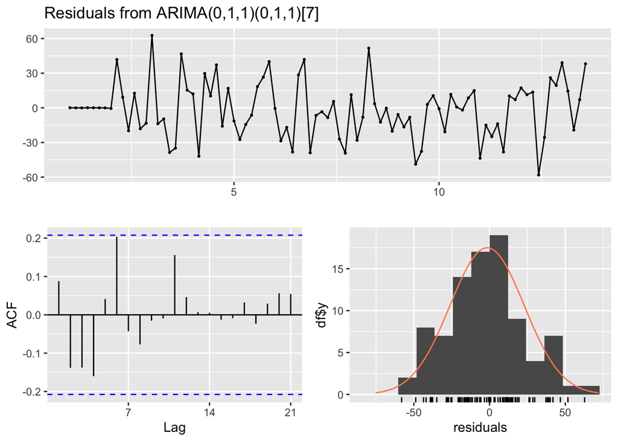

```
##
##  Ljung-Box test
##
## data:  Residuals from ARIMA(0,1,1)(0,1,1)[7]
## Q* = 14.498, df = 12, p-value = 0.27
##
## Model df: 2.   Total lags used: 14
```

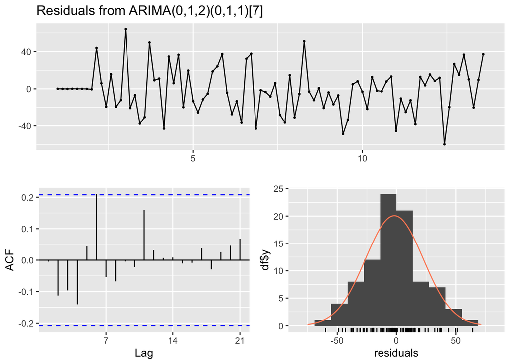

```
##
##  Ljung-Box test
##
## data:  Residuals from ARIMA(0,1,2)(0,1,1)[7]
## Q* = 11.989, df = 11, p-value = 0.3644
##
## Model df: 3.   Total lags used: 14
```

The models are then used to generate the forecast, and evaluated based on its accuracy. Since the test set contains 14 days (2 weeks) of data, 14 forecasted data will be generated.

The forecasts are evaluated with the testing data, thus the accuracy is evaluated.

As seen in the accuracy report on the performance of each model on the testing data, the first model (ARIMA(0,1,1)(0,1,1)[7]) is more accurate and better overall. This is due to the model having a lower RMSE, supported by it’s lower AICc score during the auto.arima() process.

```
##                     ME     RMSE      MAE       MPE     MAPE      MASE
## Training set -1.638138 24.43716 19.06975 -3.885874 14.74813 0.7169738
## Test set     12.751927 41.28399 30.31104  6.189661 19.46748 1.1396174
##                    ACF1 Theil's U
## Training set 0.08766976        NA
## Test set     0.14871071 0.6553712
```

```
##                     ME     RMSE      MAE       MPE     MAPE      MASE
## Training set -1.738232 24.30086 18.69961 -3.847495 14.36243 0.7030575
## Test set     12.796903 41.58482 30.73180  6.233862 19.76509 1.1554367
##                      ACF1 Theil's U
## Training set -0.004735038        NA
## Test set      0.152997223 0.6583262
```

Therefore the best ARIMA model is: (ARIMA(0,1,1)(0,1,1)[7])

#### Q3. Performance comparison

The performance between the Holt-Winters and ARIMA model are compared. Firstly, both models are used to forecast the next 14 day’s demand to correspond to the 14 data in the testing set.

Based on the accuracy results, the Holt-Winters model is considerably more accurate than the ARIMA model, with a lower RMSE value on the test set of 38.53718 as opposed to the ARIMA model’s RMSE of 41.28399.

```
##                     ME     RMSE      MAE       MPE     MAPE      MASE
## Training set -1.014639 23.09898 18.47706 -3.708049 14.26531 0.6946899
## Test set     12.025567 38.53718 28.55525  5.920676 18.50333 1.0736040
##                    ACF1 Theil's U
## Training set 0.08798640        NA
## Test set     0.07795779  0.608142
```

```
##                     ME     RMSE      MAE       MPE     MAPE      MASE
## Training set -1.638138 24.43716 19.06975 -3.885874 14.74813 0.7169738
## Test set     12.751927 41.28399 30.31104  6.189661 19.46748 1.1396174
##                    ACF1 Theil's U
## Training set 0.08766976        NA
## Test set     0.14871071 0.6553712
```

This concludes that for store 46673, the best model for forecasting lettuce demand is the Holt-Winters model: ETS(A,N,A)

### Store 4904 (California, Shattuck Sq)

#### Initial Observations

[figure not shown]

#### Time-series decomposition

[figure not shown]

#### Train-Test split

```
## Time Series:
## Start = c(1, 1)
## End = c(12, 4)
## Frequency = 7
##  [1] 176 182 347 400 406 382 324 192 274 370 332 390 384 377 232 219 376 360 422
## [20] 448 332 312 235 402 406 436 449 378 270 298 354 426 400 400 370 320 210 342
## [39] 384 410 410 380 253 254 426 428 378 412 364 262 196 376 402 360 362 322 218
## [58] 231 434 356 426 360 341 226 332 300 320 322 290 298 162 264 168 284 334 370
## [77] 270 258 206 436 362
```

```
## Time Series:
## Start = c(12, 5)
## End = c(14, 4)
## Frequency = 7
##  [1] 374 318 330 251 230 416 318 352 298 256 223 216 350 338
```

#### Training Data Plot and Time Series Decomposition

By observing the plotted time series of this store’s training data, there aren’t any clear trend or seasonal factors as seen in both grey bars being relatively larger (than that of store 46673). From this observation only, it may be possible to assume that the data is already stationary, although would not be 100% accurate.

[figure not shown]

[figure not shown]

#### Q1. Holt-Winters model

Similarly, the Holt-Winters modelling will use the ets() function as the HoltWinters() function requires information to construct the initialisation which is hard to obtain.

To determine the parameters of the ets() function, the automatic model selection function of the ets() function will be used. Additionally, the analysis of the time series decomposition will be used to verify the parameters.

```
## ETS(A,N,A)
##
## Call:
## ets(y = store_4904_train, model = "ZZZ")
##
##   Smoothing parameters:
##     alpha = 0.194
##     gamma = 1e-04
##
##   Initial states:
##     l = 329.2286
##     s = 6.3379 52.1586 56.1676 42.0506 29.5549 -91.1832
##            -95.0864
##
##   sigma:  45.6581
##
##       AIC      AICc       BIC
##  985.4413  988.5842 1009.3858
```

This can be seen in the decomposition where there is no particular trend as shown by the large grey bar. Seasonal fluctuations also remain approximately constant over time, regardless of the time, therefore is additive.

Therefore it is concluded that the optimal Holt-Winters model is ETS(A,N,A)

#### Q2. ARIMA model

For the ARIMA model, again, the Box-Jenkins procedure will be performed to select and evaluate the best model.

To formally test for the data’s stationarity, the ADF, PP and KPSS tests will be performed. The stationarity tests here indicates that the data is stationary.

```
##
##  Augmented Dickey-Fuller Test
##
## data:  store_4904_train
## Dickey-Fuller = -5.1903, Lag order = 4, p-value = 0.01
## alternative hypothesis: stationary
```

```
##
##  Phillips-Perron Unit Root Test
##
## data:  store_4904_train
## Dickey-Fuller Z(alpha) = -44.411, Truncation lag parameter = 3, p-value
## = 0.01
## alternative hypothesis: stationary
```

```
##
##  KPSS Test for Level Stationarity
##
## data:  store_4904_train
## KPSS Level = 0.28583, Truncation lag parameter = 3, p-value = 0.1
```

To further confirm that the data is in the state of stationarity, the order of differencing will be determined:

```
## [1] 0
```

```
## [1] 1
```

Results indicate that only the non-seasonal part of the data is stationary, and the seasonal part still requires first order differencing.

This can be observed in the ACF and PACF as well, as there are similar spikes to store 46673. There are significant spikes in lags 7, 14 and 21. Additionally, there are also lags in between those periods (7,14,21) such as in lags 3 and 4, 10 and 11 and so on. This suggests that there may be a seasonal MA component, thus there is a clear weekly seasonality where each day of the week is highly correlated. The PACF shows a spike in lag 1, 6 and 7, indicating a possible existence of a seasonal AR component, where the current current observation is directly influenced by its value 1,6 and 7 periods (days) ago.

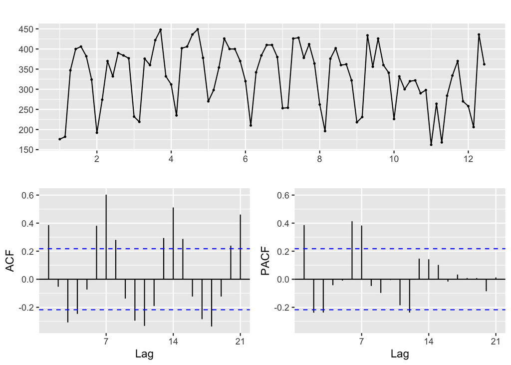

After applying the first-order seasonal differencing of lag 7, both the ndiffs() and nsdiffs() functions now has an output of 0. Indicating that the data does not require any differencing and is stationary.

```
## [1] 0
```

```
## [1] 0
```

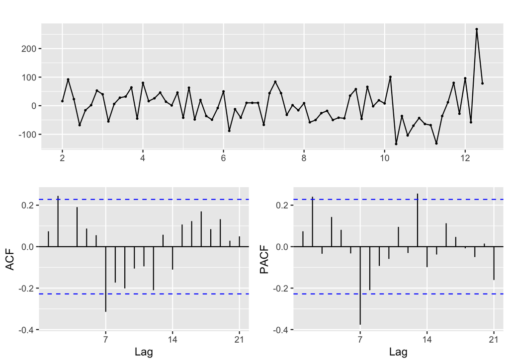

After performing differncing to obtain a stationary data set, the auto.arima() function will be used to determine the optimal model.

```
##
##  ARIMA(2,0,2)(1,1,1)[7] with drift         : Inf
##  ARIMA(0,0,0)(0,1,0)[7] with drift         : 823.6999
##  ARIMA(1,0,0)(1,1,0)[7] with drift         : 816.1322
##  ARIMA(0,0,1)(0,1,1)[7] with drift         : Inf
##  ARIMA(0,0,0)(0,1,0)[7]                    : 821.5877
##  ARIMA(1,0,0)(0,1,0)[7] with drift         : 825.4637
##  ARIMA(1,0,0)(2,1,0)[7] with drift         : 811.2152
##  ARIMA(1,0,0)(2,1,1)[7] with drift         : Inf
##  ARIMA(1,0,0)(1,1,1)[7] with drift         : Inf
##  ARIMA(0,0,0)(2,1,0)[7] with drift         : 809.9864
##  ARIMA(0,0,0)(1,1,0)[7] with drift         : 813.9763
##  ARIMA(0,0,0)(2,1,1)[7] with drift         : Inf
##  ARIMA(0,0,0)(1,1,1)[7] with drift         : Inf
##  ARIMA(0,0,1)(2,1,0)[7] with drift         : 811.606
##  ARIMA(1,0,1)(2,1,0)[7] with drift         : 807.6816
##  ARIMA(1,0,1)(1,1,0)[7] with drift         : 815.6637
##  ARIMA(1,0,1)(2,1,1)[7] with drift         : Inf
##  ARIMA(1,0,1)(1,1,1)[7] with drift         : Inf
##  ARIMA(2,0,1)(2,1,0)[7] with drift         : 807.7626
##  ARIMA(1,0,2)(2,1,0)[7] with drift         : 807.4755
##  ARIMA(1,0,2)(1,1,0)[7] with drift         : 815.8044
##  ARIMA(1,0,2)(2,1,1)[7] with drift         : Inf
##  ARIMA(1,0,2)(1,1,1)[7] with drift         : Inf
##  ARIMA(0,0,2)(2,1,0)[7] with drift         : 809.7911
##  ARIMA(2,0,2)(2,1,0)[7] with drift         : 809.4117
##  ARIMA(1,0,3)(2,1,0)[7] with drift         : Inf
##  ARIMA(0,0,3)(2,1,0)[7] with drift         : 812.1657
##  ARIMA(2,0,3)(2,1,0)[7] with drift         : 811.8566
##  ARIMA(1,0,2)(2,1,0)[7]                    : 805.0495
##  ARIMA(1,0,2)(1,1,0)[7]                    : 813.5313
##  ARIMA(1,0,2)(2,1,1)[7]                    : Inf
##  ARIMA(1,0,2)(1,1,1)[7]                    : Inf
##  ARIMA(0,0,2)(2,1,0)[7]                    : 807.5829
##  ARIMA(1,0,1)(2,1,0)[7]                    : 805.3115
##  ARIMA(2,0,2)(2,1,0)[7]                    : 806.9048
##  ARIMA(1,0,3)(2,1,0)[7]                    : Inf
##  ARIMA(0,0,1)(2,1,0)[7]                    : 809.7422
##  ARIMA(0,0,3)(2,1,0)[7]                    : 809.8773
##  ARIMA(2,0,1)(2,1,0)[7]                    : 805.3311
##  ARIMA(2,0,3)(2,1,0)[7]                    : 809.2759
##
##  Best model: ARIMA(1,0,2)(2,1,0)[7]
```

Results show that the optimal ARIMA model is ARIMA(1,0,2)(2,1,0)[7], with the next best alternative model of ARIMA being ARIMA(1,0,1)(2,1,0)[7]. Similar to store 46673, the optimal ARIMA model has it that seasonal differencing is required, shown in the D=1 in both models.

The candidate models will now be trained:

Residual analysis will be performed to ensure that the residuals are not intercorrelated.

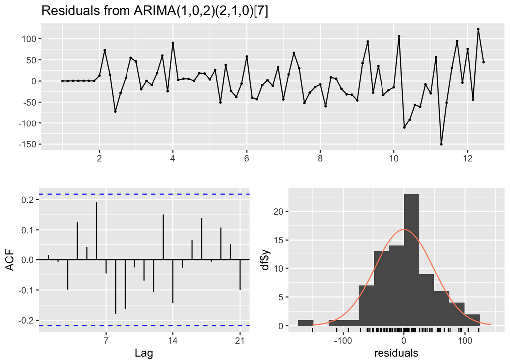

```
##
##  Ljung-Box test
##
## data:  Residuals from ARIMA(1,0,2)(2,1,0)[7]
## Q* = 17.243, df = 9, p-value = 0.04504
##
## Model df: 5.   Total lags used: 14
```

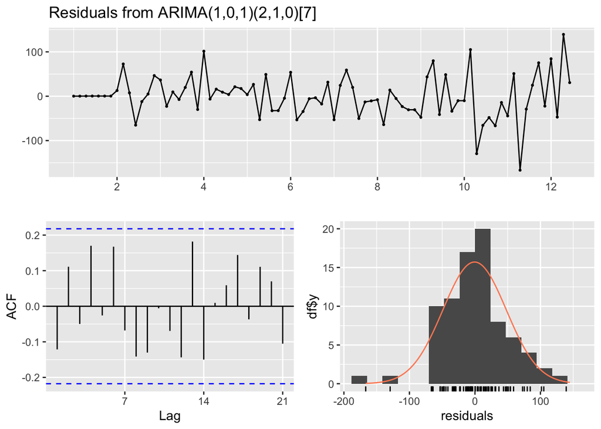

```
##
##  Ljung-Box test
##
## data:  Residuals from ARIMA(1,0,1)(2,1,0)[7]
## Q* = 19.433, df = 10, p-value = 0.0351
##
## Model df: 4.   Total lags used: 14
```

The models are used to perform the forecasting, and evaluated based on its accuracy. Again, the test set contains 14 days (2 weeks) worth of data, therefore 14 forecasted data will be generated.

The accuracy of the models’ forecasts are evaluated with the testing data.

```
##                        ME     RMSE      MAE       MPE     MAPE      MASE
## Training set   0.06174846 47.29793 34.83913 -1.266520 11.56128 0.7397691
## Test set     -12.73217671 43.87772 35.32210 -5.882579 11.98228 0.7500244
##                     ACF1 Theil's U
## Training set  0.01549733        NA
## Test set     -0.28950555 0.5625631
```

```
##                      ME     RMSE      MAE       MPE     MAPE      MASE
## Training set -0.5390384 48.12504 35.12393 -1.657746 11.85528 0.7458167
## Test set     -2.8671278 41.37553 33.59529 -2.535405 11.37570 0.7133577
##                    ACF1 Theil's U
## Training set -0.1212624        NA
## Test set     -0.3400886 0.5575332
```

Therefore the best ARIMA model is: ARIMA(1,0,1)(2,1,0)[7]

#### Q3. Performance comparison

The performance between the Holt-Winters and ARIMA model for store 4904 are compared. Initially, both models are used to forecast the next 14 day’s demand to match the 14 data in the testing set

```
##                      ME     RMSE      MAE       MPE      MAPE      MASE
## Training set -0.9194867 43.04688 32.02198 -2.351651 10.999318 0.6799502
## Test set     -9.7799936 37.75467 28.39140 -3.682129  9.266691 0.6028589
##                     ACF1 Theil's U
## Training set -0.06676219        NA
## Test set      0.13061792 0.4259769
```

```
##                        ME     RMSE      MAE       MPE     MAPE      MASE
## Training set   0.06174846 47.29793 34.83913 -1.266520 11.56128 0.7397691
## Test set     -12.73217671 43.87772 35.32210 -5.882579 11.98228 0.7500244
##                     ACF1 Theil's U
## Training set  0.01549733        NA
## Test set     -0.28950555 0.5625631
```

This concludes that for store 4904, the best model for forecasting is the Holt-Winters model: ETS(A,N,A)

### Store 12631 (New York, Myrtle Avenue)

#### Initial Observations

[figure not shown]

#### Time-series decomposition

[figure not shown]

#### Train-Test split

```
## Time Series:
## Start = c(1, 1)
## End = c(13, 5)
## Frequency = 7
##  [1] 232 227 181 221 229 237 235 244 218 205 248 153 222 262 259 274 250 209 202
## [20] 207 251 256 246 251 214 218 245 268 236 352 190 280 232 243 217 309 354 212
## [39] 264 252 251 306 291 328 221 199 249 241 265 279 313 233 324 354 324 307 316
## [58] 324 203 369 246 267 256 313 277 257 264 238 259 361 316 263 233 256 220 258
## [77] 237 350 271 194 244 289 253 318 371 351 279 236 204
```

```
## Time Series:
## Start = c(13, 6)
## End = c(15, 5)
## Frequency = 7
##  [1] 252 241 279 232 245 282 230 294 235 376 366 229 234 232
```

#### Training data Plot and Time Series Decomposition

The plotted time series of store 12631 training data shows a relatively weak positive trend. When observed through the time series decomposition, it can be seen that trend has a shorter grey bar in the decomposition. This can be interpreted as trend contributing to a greater proportion of the variation of the time series, hence there is a trend component in the time series.

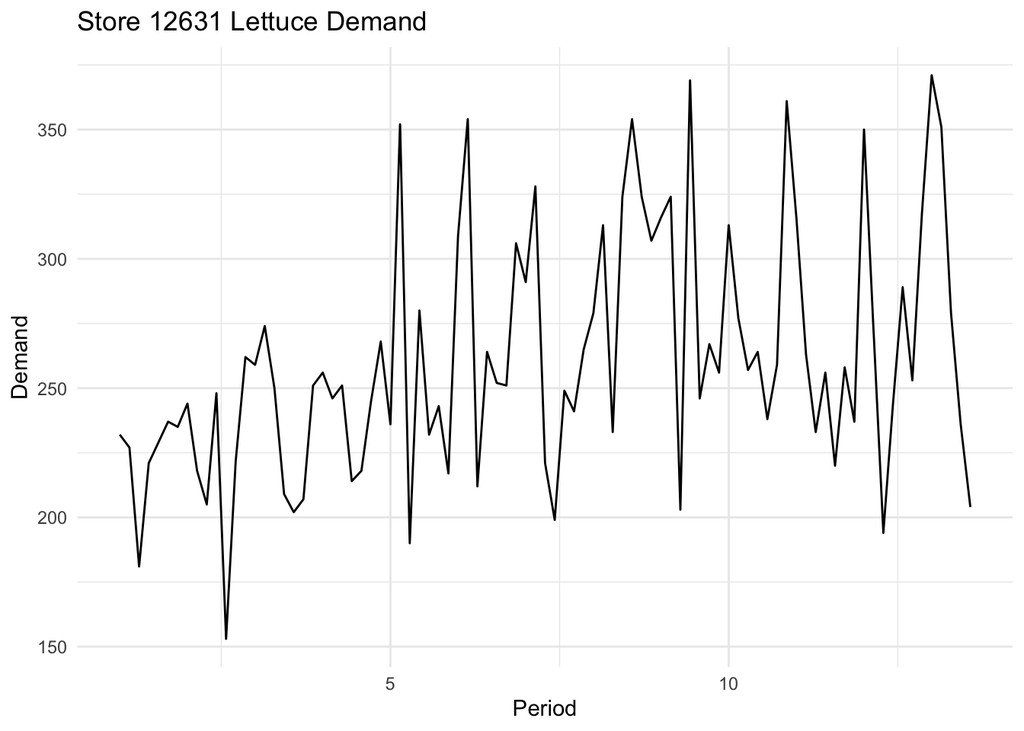

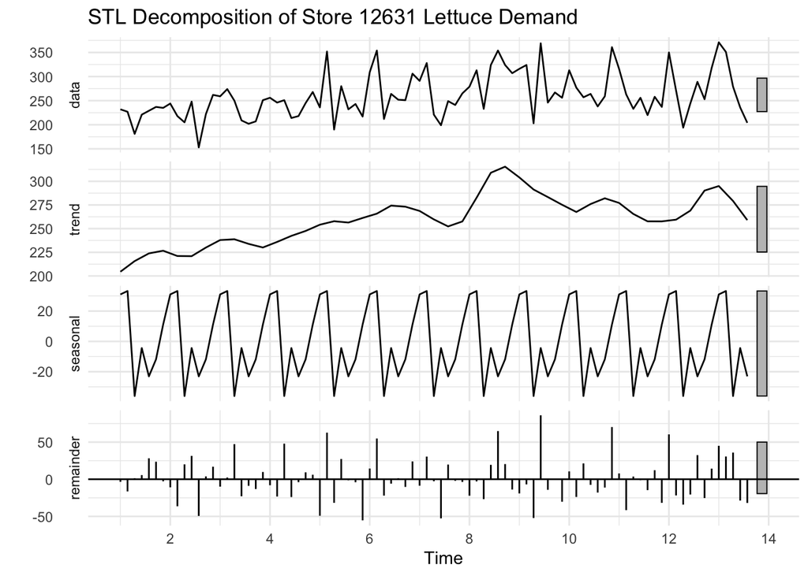

#### Q1. Holt-Winters model

Again, the Holt-Winters model will use the ets() function through the automatic model selection function etc(ZZZ). And the analysis of the time series decomposition will be used to verify the parameters.

```
## ETS(M,Ad,M)
##
## Call:
## ets(y = store_12631_train, model = "ZZZ")
##
##   Smoothing parameters:
##     alpha = 1e-04
##     beta  = 1e-04
##     gamma = 1e-04
##     phi   = 0.9753
##
##   Initial states:
##     l = 214.8392
##     b = 1.968
##     s = 1.0449 0.9662 0.9145 0.9813 0.853 1.1398
##            1.1003
##
##   sigma:  0.1389
##
##      AIC     AICc      BIC
## 1050.788 1055.641 1083.140
```

The ets results show that the Holt-Winters model for store 12631 has a multiplicative error, an additively damped trend and a multiplicative seasonal factor, ETA(M,Ad,M). The model smoothing paramers are alpha = 1e-04, beta = 1e-04 and gamma = 1e-04. The initial state values is the constant l = 214.8392, initial trend is 1.968 and initial seasonal factors for the first few periods are 1.0449, 0.9662, 0.9145, 0.9813 ,0.853, 1.1398, 1.1003.

The time series decomposition shows that the errors and the seasonal pattern is proportional to the level of the time series. Where as the trend is initially additive until around half of the total observations, but then the trend is damped, resulting in its effects on the future forecast to diminish over time.

Therefore it can be concluded that the optimal Holt-Winters model is ETS(M,Ad,M)

#### Q2. ARIMA model

The Box-Jenkins procedure will be performed to select and evaluate the best ARIMA model.

To formally test for the data’s stationarity, the ADF, PP and KPSS tests will be performed. Results indicate that the stationarity test are conflicting. The ADF and PP tests suggests that the data is stationary, with both having small p-values, thus leads to the rejection of the null hypothesis that the data is non-stationary. However, the KPSS test result indicates that the time series data, is in fact, non-stationary as the KPSS test result has a small p-value, leading to the rejection of the null hypothesis of stationarity.

```
##
##  Augmented Dickey-Fuller Test
##
## data:  store_12631_train
## Dickey-Fuller = -4.8181, Lag order = 4, p-value = 0.01
## alternative hypothesis: stationary
```

```
##
##  Phillips-Perron Unit Root Test
##
## data:  store_12631_train
## Dickey-Fuller Z(alpha) = -75.753, Truncation lag parameter = 3, p-value
## = 0.01
## alternative hypothesis: stationary
```

```
##
##  KPSS Test for Level Stationarity
##
## data:  store_12631_train
## KPSS Level = 0.96112, Truncation lag parameter = 3, p-value = 0.01
```

This can be supported by the observations made in the time series composition, where there indeed is non-stationarity, most likely due to the trend.

The ndiffs() and nsdiffs() functions are then use to find the order of differencing required for the time series data to be stationary.

The results show that first-order non-seasonal differencing should be performed, whereas no seasonal differencing is required. This further verifies that store 12631 data has a significant trend component, rather than a seasonal component.

```
## [1] 1
```

```
## [1] 0
```

To further support the fact that the time series is non-stationary, The ACF shows a slow decay from lag 7 to lag 21. This suggests that the past observations are strongly correlated with current values over a long period, thus confirming that there is a trend in the time series data and differencing is required.

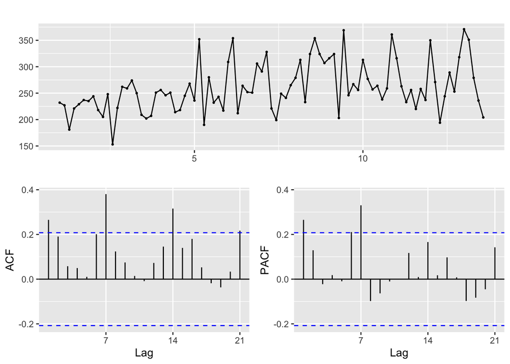

```
## [1] 0
```

```
## [1] 0
```

The ACF and PACF plots after performing first order differencing shows that there is now no exponential decay from a certain lag period. However, now there is a negative spike at lag 1, possibly suggesting that the model integrates an MA component of 1 as the strong negative correlation suggests a strong relationship between the observation and the preceding observation. Thus The few spikes in lags 7, 14 and 21 suggests that the data may not be entirely stationary where there is weekly seasonality similar to stores 46673 and 4904 as observed. This opposes the nsdiffs() function results, therefore it is best to proceed with the auto.arima() function to determine the optimal ARIMA parameters to account for trend and/or seasonality.

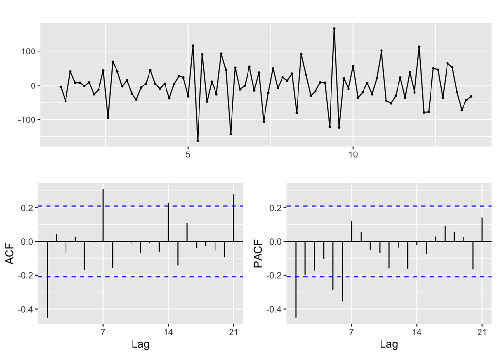

The auto.arima() function is then used on the training set of store 12631, where d = 1 and D = 1 to account that there is a possibility that there both trend and seasonality components, therefore must be adjusted using differencing for both.

```
##
##  ARIMA(2,1,2)(1,1,1)[7]                    : Inf
##  ARIMA(0,1,0)(0,1,0)[7]                    : 914.5263
##  ARIMA(1,1,0)(1,1,0)[7]                    : 874.1745
##  ARIMA(0,1,1)(0,1,1)[7]                    : 841.9876
##  ARIMA(0,1,1)(0,1,0)[7]                    : Inf
##  ARIMA(0,1,1)(1,1,1)[7]                    : Inf
##  ARIMA(0,1,1)(0,1,2)[7]                    : Inf
##  ARIMA(0,1,1)(1,1,0)[7]                    : 853.9169
##  ARIMA(0,1,1)(1,1,2)[7]                    : Inf
##  ARIMA(0,1,0)(0,1,1)[7]                    : Inf
##  ARIMA(1,1,1)(0,1,1)[7]                    : 844.0699
##  ARIMA(0,1,2)(0,1,1)[7]                    : 844.0851
##  ARIMA(1,1,0)(0,1,1)[7]                    : 859.2405
##  ARIMA(1,1,2)(0,1,1)[7]                    : Inf
##
##  Best model: ARIMA(0,1,1)(0,1,1)[7]
```

Results show that the optimal ARIMA model is ARIMA(0,1,1)(0,1,1)[7], with the alternative model of ARIMA(1,1,1)(0,1,1)[7]. The model includes both the non-seasonal and seasonal first-order differencing.

The candidate models will now be trained:

Residual analysis will be performed to ensure that the residuals are not correlated

The results show that all the lags of the ACF are within the 95% confidence interval, indicating that there are no correlation between the residuals.

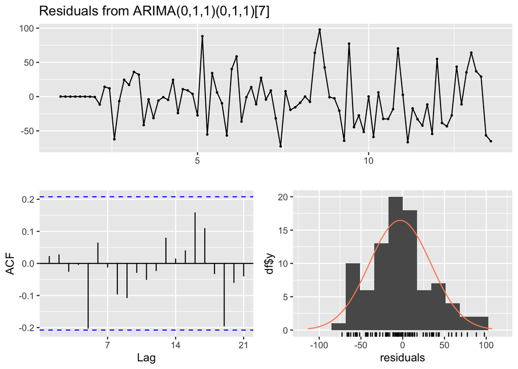

```
##
##  Ljung-Box test
##
## data:  Residuals from ARIMA(0,1,1)(0,1,1)[7]
## Q* = 7.8192, df = 12, p-value = 0.7991
##
## Model df: 2.   Total lags used: 14
```

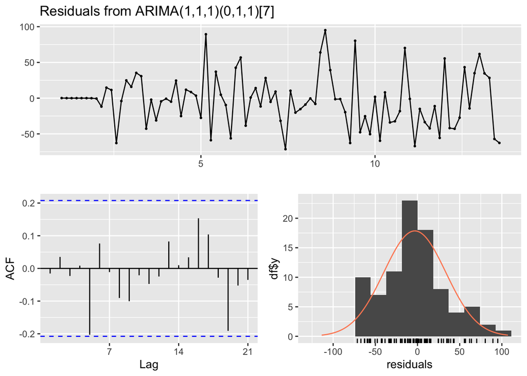

```
##
##  Ljung-Box test
##
## data:  Residuals from ARIMA(1,1,1)(0,1,1)[7]
## Q* = 7.6574, df = 11, p-value = 0.7436
##
## Model df: 3.   Total lags used: 14
```

The selected models will then perform the forecasting, and is again, evaluated based on its accuracy. Once again, the there will be 14 forecasted data generated from the model, as the test set is equivalent 14 days (2 weeks) of data.

The models forecasts will be evaluated through its accuracy.

```
##                      ME     RMSE      MAE       MPE     MAPE      MASE
## Training set  -3.105414 36.69961 27.74017 -2.939794 10.76798 0.7502288
## Test set     -20.148118 43.45155 37.18376 -9.614202 14.42021 1.0056294
##                    ACF1 Theil's U
## Training set 0.02290261        NA
## Test set     0.02730209 0.7079867
```

```
##                      ME     RMSE      MAE       MPE     MAPE      MASE
## Training set  -3.211743 36.72372 27.76791 -2.972695 10.78586 0.7509792
## Test set     -20.107711 43.41912 37.05857 -9.590493 14.37584 1.0022437
##                     ACF1 Theil's U
## Training set -0.01553457        NA
## Test set      0.02443076 0.7085131
```

#### Q3. Performance comparison

The performance of the Holt-Winters and ARIMA model for store 12631 will be compared by using the forecast for the next 14 days’ demand to match the 14 data in the testing set.

```
##                      ME     RMSE      MAE       MPE     MAPE      MASE
## Training set  -1.077097 34.11242 26.09866 -2.108286 10.08561 0.7058346
## Test set     -19.235015 44.30622 36.85583 -9.276175 14.25979 0.9967607
##                      ACF1 Theil's U
## Training set  0.061529822        NA
## Test set     -0.001611319 0.7245148
```

```
##                      ME     RMSE      MAE       MPE     MAPE      MASE
## Training set  -3.211743 36.72372 27.76791 -2.972695 10.78586 0.7509792
## Test set     -20.107711 43.41912 37.05857 -9.590493 14.37584 1.0022437
##                     ACF1 Theil's U
## Training set -0.01553457        NA
## Test set      0.02443076 0.7085131
```

### Store 20974 (New York, Whitney Avenue)

#### Initial Observations

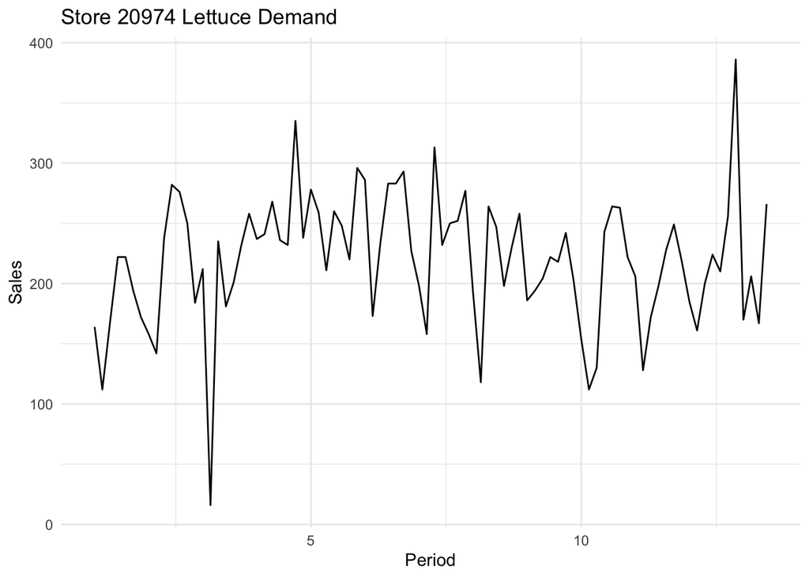

#### Time-series decomposition

Through initial observation the plotted time series of this store’s training data, there aren’t any clear trend or seasonal factors as both grey bars being relatively long (than that of store 46673 and store 12631). From this observation, it may be possible to assume that the data is already stationary, although further testing is required to verify such assumption

[figure not shown]

#### Train-Test split

```
## Time Series:
## Start = c(1, 1)
## End = c(11, 4)
## Frequency = 7
##  [1] 164 112 168 222 222 194 172 158 142 238 282 276 250 184 212  16 235 181 201
## [20] 232 258 237 241 268 236 232 335 238 278 259 211 260 248 220 296 286 173 234
## [39] 283 283 293 227 198 158 313 232 250 252 277 192 118 264 247 198 230 258 186
## [58] 194 204 222 218 242 203 154 112 130 243 264 263 222 206 128 172 198
```

[output not shown]

#### Q1. Holt-Winters model

For store 20974, the Holt-Winters model will once again use the ets() function to construct the model. The parameters will also be ZZZ in order to use the automatic model selection function. And the parameters will be verified using the data’s time series decomposition.

```
## ETS(A,N,A)
##
## Call:
## ets(y = store_20974_train, model = "ZZZ")
##
##   Smoothing parameters:
##     alpha = 0.1905
##     gamma = 1e-04
##
##   Initial states:
##     l = 209.6333
##     s = 12.0706 29.4123 17.4096 18.8407 4.0938 -65.3266
##            -16.5004
##
##   sigma:  43.4163
##
##      AIC     AICc      BIC
## 886.9883 890.4803 910.0289
```

This can be seen in the decomposition where there is no trend as shown by the large grey bar. Seasonal fluctuations also remain approximately constant over time, regardless of the time and is additive.

Thus it is concluded that the optimal Holt-Winters model is ETA(A,N,A)

#### Q2. ARIMA model

For the ARIMA model, again, the Box-Jenkins procedure will be performed to select and evaluate the best model.

Again, the ADF, PP and KPSS tests will be performed to test the data’s sationarity. The stationarity tests here indicates that the data is stationary as the ADF and PP rejects the null hypothesis of non-staionarity, and the KPSS test results fails to reject the null hypothesis of stationarity. Based on these results, differencing may not be required.

```
##
##  Augmented Dickey-Fuller Test
##
## data:  store_20974_train
## Dickey-Fuller = -3.5721, Lag order = 4, p-value = 0.04182
## alternative hypothesis: stationary
```

```
##
##  Phillips-Perron Unit Root Test
##
## data:  store_20974_train
## Dickey-Fuller Z(alpha) = -48.35, Truncation lag parameter = 3, p-value
## = 0.01
## alternative hypothesis: stationary
```

```
##
##  KPSS Test for Level Stationarity
##
## data:  store_20974_train
## KPSS Level = 0.25367, Truncation lag parameter = 3, p-value = 0.1
```

To further confirm stationarity, the order of differencing for this store’s data will be determined:

```
## [1] 0
```

```
## [1] 0
```

The results of the ndiffs() and nsdiffs() shows that there are no differencing required for both the non-seasonal and seasonal parts of the data.

However, this information is opposed when observing the ACF and PACF plots. There is a spike in lag 1 and lag 7 in the ACF, indicating a possible AR component of at least 1, and how there may be seasonality with periods of 7 which means an AR or MA component of 7 may be required for the ARIMA model to capture such spike. Although this means no differencing is needed as the data is statistically stationary, but must still model the autocorrelation structure of this store’s data through the AR and MA components.

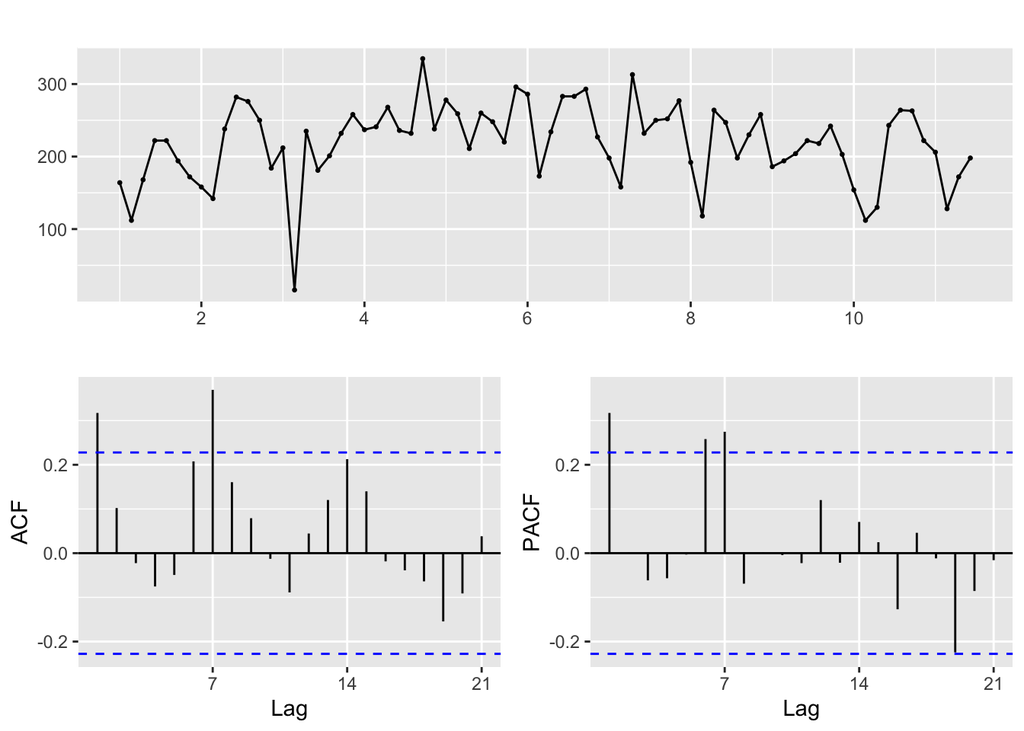

With that, the auto.arim() will be used to determine the optimal ARIMA model.

```
##
##  ARIMA(2,0,2)(1,1,1)[7] with drift         : Inf
##  ARIMA(0,0,0)(0,1,0)[7] with drift         : 740.4023
##  ARIMA(1,0,0)(1,1,0)[7] with drift         : 731.7102
##  ARIMA(0,0,1)(0,1,1)[7] with drift         : Inf
##  ARIMA(0,0,0)(0,1,0)[7]                    : 738.4467
##  ARIMA(1,0,0)(0,1,0)[7] with drift         : 741.2634
##  ARIMA(1,0,0)(2,1,0)[7] with drift         : 731.3598
##  ARIMA(1,0,0)(2,1,1)[7] with drift         : Inf
##  ARIMA(1,0,0)(1,1,1)[7] with drift         : Inf
##  ARIMA(0,0,0)(2,1,0)[7] with drift         : 732.0508
##  ARIMA(2,0,0)(2,1,0)[7] with drift         : 732.2008
##  ARIMA(1,0,1)(2,1,0)[7] with drift         : 731.7935
##  ARIMA(0,0,1)(2,1,0)[7] with drift         : 732.1372
##  ARIMA(2,0,1)(2,1,0)[7] with drift         : 734.3376
##  ARIMA(1,0,0)(2,1,0)[7]                    : 729.0742
##  ARIMA(1,0,0)(1,1,0)[7]                    : 729.4903
##  ARIMA(1,0,0)(2,1,1)[7]                    : Inf
##  ARIMA(1,0,0)(1,1,1)[7]                    : Inf
##  ARIMA(0,0,0)(2,1,0)[7]                    : 729.8682
##  ARIMA(2,0,0)(2,1,0)[7]                    : 729.8235
##  ARIMA(1,0,1)(2,1,0)[7]                    : 729.4311
##  ARIMA(0,0,1)(2,1,0)[7]                    : 729.8618
##  ARIMA(2,0,1)(2,1,0)[7]                    : 731.8772
##
##  Best model: ARIMA(1,0,0)(2,1,0)[7]
```

The candidate models will now be trained:

Residual analysis will be performed to ensure that the residuals are not intercorrelated.

The results show that all the lags of the ACF are within the 95% confidence interval, indicating that there are no correlation between the residuals.

[figure not shown]

[output not shown]

[figure not shown]

[output not shown]

The models are used to perform the forecasting, and evaluated based on its accuracy. Once again, the test set contains 14 days (2 weeks) worth of data, therefore 14 forecasted data will be generated.

The models accuracy are evaluated using the testing data through the RMSE value.

Results show that the best model (one with lowest AICc score) has a significantly higher RMSE, therefore the alternative model ARIMA(1,0,1)(2,1,0)[7] is the better model This concludes that the optimal model is ARIMA(1,0,1)(2,1,0)[7].

```
##                      ME     RMSE      MAE       MPE     MAPE      MASE
## Training set  0.1857755  52.7249 41.44152 -18.01486 34.28536 0.8839802
## Test set     93.7099562 109.1868 93.70996  31.42940 31.42940 1.9989071
##                     ACF1 Theil's U
## Training set -0.03909885        NA
## Test set      0.37223432  1.736962
```

[output not shown]

Therefore, the best ARIMA model for this store is: ARIMA(1,0,1)(2,1,0)[7]

#### Q3. Performance comparison

The performance of the Holt-Winters and ARIMA model for store 20974 is compared through the forecast of the next 14 days’ lettuce demand, again, to match the 14 data of the testing set.

The Holt-Winters model and ARIMA model for the store 20974 shows that the ARIMA model is the better model due to its significantly lower RMSE at 89.93421 compared to the Holt-Winters model of 107.47122.

```
##                      ME      RMSE     MAE       MPE     MAPE      MASE
## Training set -0.9560356  40.69057 33.6634 -13.46909 26.18756 0.7180669
## Test set     80.3486130 107.47122 81.2405  25.68648 26.14622 1.7329238
##                    ACF1 Theil's U
## Training set 0.08618948        NA
## Test set     0.33139300  1.633018
```

[output not shown]

This concludes that for store 20974, the best model for forecasting is the ARIMA model: ARIMA(1,0,1)(2,1,0)[7]